# Survey Analysis

## Ques1: Distribution of Tool types people work with.

Also investingated how many people chose single and multiple answers. recoded: All Python responses to Python/Jupiter Notebooks and removed not sure repsones

```r
## Since this is a multiple choice question, we need to separate the (unequal) number of answers given by each respondent
## Note: some people selected Other and put in their version, we need to identify those as well
## Defined strings = strings up to the first comma
## First, we create a variable containing all strings to match with response data. We take names up to the first comma, which will be our separator.
## **Notice double spaces in names of certain strings: Computing, Command-line,
SciToolsType.defined <- c("Computing Web-based Platform - A website providing computing resources and  possibly data",
"Web-based tool - A tool that runs in your web browser but doesn't necessarily provide access to data",
"Bioconductor R packages",
"Other R packages (not Bioconductor)",
"Jupyter Notebooks",
"Desktop Application - A tool that runs on your desktop environment with a GUI",
"Database/Ontology",
"Plug-in - A software component encapsulating a set of related functions, which are not standalone, i.e. depend upon other software for its use, e.g. a Javascript widget, or a plug-in, extension add-on etc. that extends the function of some existing to",
"Command-line tool/Other scripts - A tool  that works with a command-line interface or environment",
"Suite - multiple tools that work together")

## Residual strings = all comma separated strings after the first comma
SciToolsType.residual_string <- c("which are not standalone", "i.e. depend upon other software for its use", "e.g. a Javascript widget",
                                  "or a plug-in", "extension add-on etc. that extends the function of some existing to",
                                  "where Jupyter notebooks are a component")

## Find all relevant unique strings in a vector
SciToolsType.vec <- wdat %>% select(Timestamp, toolType)  %>%
  bind_cols(split_string_multiple(.$toolType, ",", "ans")) %>%     # split string columns into multiple columns
  select(-toolType) %>%                                            # remove original variable
  pivot_longer(cols = -Timestamp, names_to = "Answer", values_to = "vals") %>%  # take data into long form to aid filtering operations
  filter(!is.na(vals)) %>%                                         # filter NA values
  mutate(vals = str_trim(vals, side = "both")) %>%                 # remove leading and trailing white spaces in the strings
  count(vals) %>% filter(!vals %in% c(SciToolsType.residual_string)) %>% pull(vals)  # remove residual strings from the vectors
## The drawback is when the user provides comma-separated response. Then we need to manually include that in residual strings

############RECODE 01: All Python responses to Python/Jupiter Notebooks######################
## 1. Remove Not Sure
## 2. All Python responses to Python/Jupiter Notebooks

## Consider each timestamp (all unique) as an identifier
tab.toolType <- wdat %>% select(Timestamp, toolType)  %>%
  bind_cols(split_string_multiple(.$toolType, ",", "ans")) %>%     # split string columns into multiple columns
  select(-toolType) %>%                                            # remove original variable
  pivot_longer(cols = -Timestamp, names_to = "Answer", values_to = "vals") %>%  # take data into long form to aid filtering operations
  filter(!is.na(vals)) %>%                                         # filter NA values
  mutate(vals = str_trim(vals, side = "both")) %>%                 # remove leading and trailing white spaces in the strings
  filter(vals %in% SciToolsType.vec) %>% arrange(Timestamp, Answer) %>%   # keep only the actual tool names (defined up to first comma)
  group_by(Timestamp) %>%  mutate(`answer_count` = 1:n()) %>% ungroup() %>%  # create a variable to count the number of answers by each respondent
  mutate(Answer = paste0("ans_", answer_count)) %>%
  ## RECODE 01: Python issue and Not Sure removal
  filter(!vals %in% c("Not Sure")) %>%
  mutate(vals = case_when(str_detect(vals, 'Python|Jupyter') ~ "Python/Jupyter Notebooks",
                           TRUE ~ vals))
```

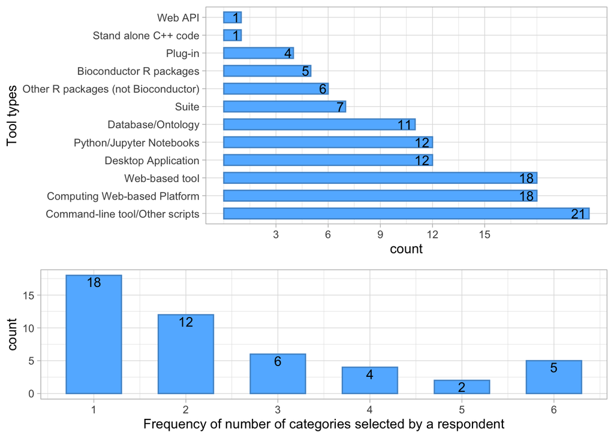

```r
ggpubr::ggarrange(
## Frequency distribution of the categories
tab.toolType %>% separate(col = vals, into = c("vals", "fat"), sep = " - ") %>% select(-fat) %>%
ggplot(aes(y = forcats::fct_infreq(vals))) +
  geom_bar(fill = "steelblue1", col = "steelblue3", width = 0.6) +
  geom_text(stat = 'count', aes(label = after_stat(count)), hjust = 1.2) +
  scale_x_continuous(breaks = seq(3, 15, by = 3)) +
  labs(x = "count", y = "Tool types") +
  #scale_y_discrete(labels = scales::wrap_format(70)) +
  theme_light(),

## How many single and multiple responses
tab.toolType %>% group_by(Timestamp) %>%
  summarise(answers_freq = max(answer_count)) %>% ungroup() %>%
  ggplot(aes(answers_freq)) +
  geom_bar(fill = "steelblue1", col = "steelblue3", width = 0.6) +
  geom_text(stat = 'count', aes(label = after_stat(count)), vjust = 1.2) +
  scale_x_continuous(breaks = 1:6) +
  labs(y = "count", x = "Frequency of number of categories selected by a respondent") +
  theme_light(),
  ncol = 1, heights = c(1.5, 1)
)
```

## Ques2: Distribution of Data types people work with.

Also investigated how many people chose single and multiple answers.

recoded All One off “other” responses to multiple data types

1. Merge the other response types into “Multiple data types” category

```r
## Since this is a multiple choice question, we need to separate the (unequal) number of answers given by each respondent
## Note: some people selected Other and put in their version, we need to identify those as well
## Defined strings = strings up to the first comma
DataTypes.defined <- c("Omics - proteomics", "Clinical", "Imaging", "Supports multiple types of data")
## Residual strings = all comma separated strings after the first comma
DataTypes.residual_strings <- c("genomics", "metabolomics")

## Find all relevant unique strings in a vector
DataTypes.vec <- wdat %>% select(Timestamp, dataType)  %>%
  bind_cols(split_string_multiple(.$dataType, ",", "ans")) %>% select(-dataType) %>%
  pivot_longer(cols = -Timestamp, names_to = "Answer", values_to = "vals") %>%
  filter(!is.na(vals)) %>% mutate(vals = str_trim(vals, side = "both")) %>%
  count(vals) %>% filter(!vals %in% c(DataTypes.residual_strings)) %>% pull(vals)

## Consider each timestamp (all unique) as an identifier
tab.dataType <- wdat %>% select(Timestamp, dataType)  %>%
  bind_cols(split_string_multiple(.$dataType, ",", "ans")) %>% select(-dataType) %>%
  pivot_longer(cols = -Timestamp, names_to = "Answer", values_to = "vals") %>%
  filter(!is.na(vals)) %>%
  mutate(vals = str_trim(vals, side = "both")) %>%
  filter(vals %in% DataTypes.vec) %>% arrange(Timestamp, Answer) %>%
  group_by(Timestamp) %>%  mutate(`answer_count` = 1:n()) %>% ungroup() %>%
  mutate(Answer = paste0("ans_", answer_count)) %>%
  ##################### Recode the one-off other categories ##################
  mutate(vals = case_when(str_detect(vals, 'Omics|Imaging|Clinical') ~ vals,
                          TRUE ~ "Multiple data types")) %>%
  ## Add the full category names again
  mutate(vals = if_else(vals == "Omics - proteomics", true = "Omics - proteomics, genomics, metabolomics", false = vals))

#wdat$dataType %>% table()
```

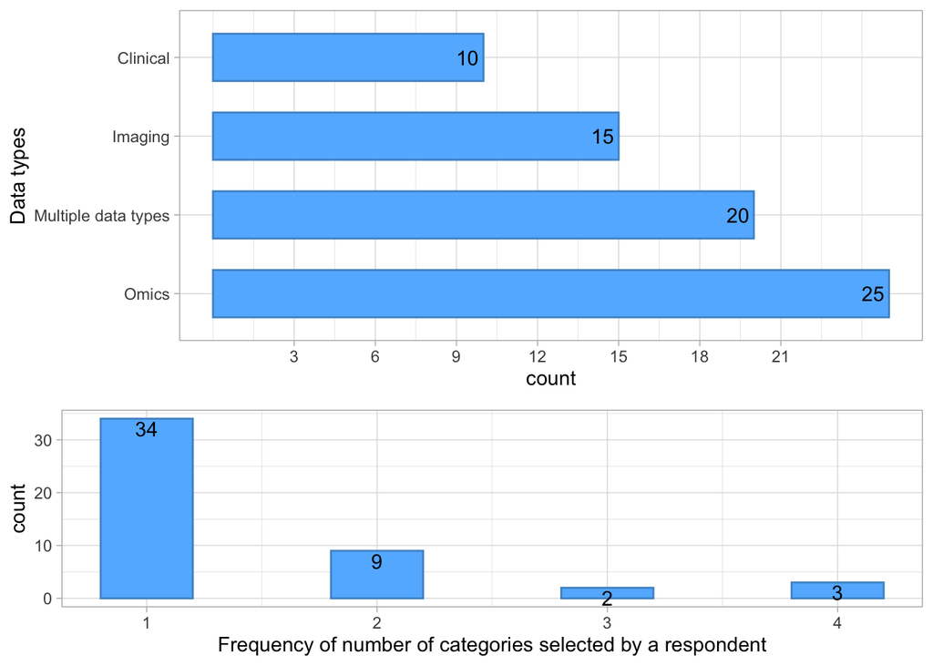

```r
ggpubr::ggarrange(
## Frequency distribution of the categories
tab.dataType %>% separate(col = vals, into = c("vals", "fat"), sep = " - ") %>% select(-fat) %>%
ggplot(aes(y = forcats::fct_infreq(vals))) +
  geom_bar(fill = "steelblue1", col = "steelblue3", width = 0.6) +
  geom_text(stat = 'count', aes(label = after_stat(count)), hjust = 1.2) +
  scale_x_continuous(breaks = seq(3, 21, by = 3)) +
  labs(x = "count", y = "Data types") +
  theme_light(),

## How many single and multiple responses
tab.dataType  %>% group_by(Timestamp) %>%
  summarise(answers_freq = max(answer_count)) %>% ungroup() %>%
  ggplot(aes(answers_freq)) +
  geom_bar(fill = "steelblue1", col = "steelblue3", width = 0.4) +
  geom_text(stat = 'count', aes(label = after_stat(count)), vjust = 1.2) +
  scale_x_continuous(breaks = 1:6) +
  labs(y = "count", x = "Frequency of number of categories selected by a respondent") +
  theme_light(),
  ncol = 1, heights = c(1.5, 1)
)
```

```r
df.dataType2 <- wdat %>% select(Timestamp, Link = `If you feel comfortable, please provide a link to your tool here.`,
                roles, experience, dataType) %>%
  mutate(experience = fct_relevel(factor(experience), "1", "2-4", "5-9")) %>%
  bind_cols(split_string_multiple(.$dataType, ",", "ans")) %>%
  select(-dataType) %>%
  pivot_longer(cols = -c(Timestamp, Link, experience, roles), names_to = "Answer", values_to = "vals") %>%
  filter(!is.na(vals)) %>% mutate(vals = str_trim(vals, side = "both")) %>%
  filter(vals %in% DataTypes.vec) %>% arrange(Timestamp, Answer) %>%
  separate(col = vals, into = c("vals", "fat"), sep = " - ") %>% select(-fat) %>%
  #### Recoding other one-off categories
  mutate(vals = case_when(str_detect(vals, 'Omics|Imaging|Clinical') ~ vals,
                          TRUE ~ "Multiple data types"))
```

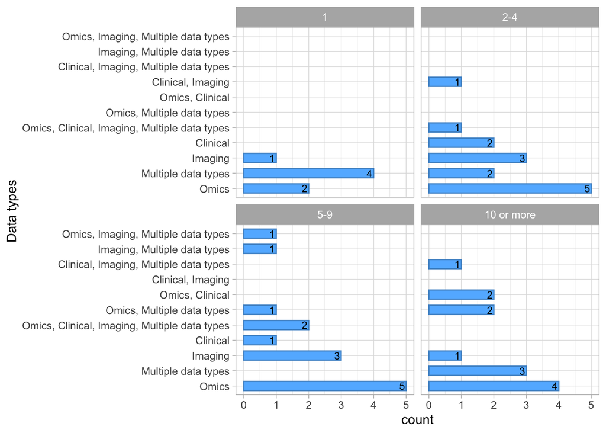

```r
## Plot: data types selections together
df.dataType2 %>% rename(dataType = vals) %>%
  group_by(Timestamp, Link, experience, roles) %>%
  summarise(selections = str_c(dataType, collapse =", ")) %>% ungroup() %>%
  mutate(selections = if_else(selections == "Multiple data types, Multiple data types", "Multiple data types", selections)) %>%
  ggplot(aes(y = fct_infreq(selections))) +
  geom_bar(fill = "steelblue1", col = "steelblue3", width = 0.6) +
  geom_text(stat = 'count', aes(label = after_stat(count)), hjust = 1.2, size = 3) +
  labs(x = "count", y = "Data types") +
  facet_wrap(~experience) +
  theme_light()
```

## Ques3: Distribution of current role on the tool development/maintenance projects.

Also investigated how many people chose single and multiple answers.

Recoded: “Principal Investigator” into Manager/ advisor.

```r
## Since this is a multiple choice question, we need to separate the (unequal) number of answers given by each respondent
## Note: some people selected Other and put in their version, we need to identify those as well
## Defined strings = strings up to the first comma
Roles.defined <- c("Manager/advisor", "Software Developer/Maintainer", "Outreach Specialist",
                   "Trainee - postdoc", "Trainee - graduate student")
Roles.residual_strings <- NULL

## Find all relevant unique strings in a vector
Roles.vec <- wdat %>% select(Timestamp, roles)  %>%
  bind_cols(split_string_multiple(.$roles, ",", "ans")) %>% select(-roles) %>%
  pivot_longer(cols = -Timestamp, names_to = "Answer", values_to = "vals") %>%
  filter(!is.na(vals)) %>%
  mutate(vals = str_trim(vals, side = "both")) %>%
  count(vals) %>% filter(!vals %in% c(Roles.residual_strings)) %>%
  pull(vals)


## Consider each timestamp (all unique) as an identifier
tab.Roles <- wdat %>% select(Timestamp, roles)  %>%
  bind_cols(split_string_multiple(.$roles, ",", "ans")) %>% select(-roles) %>%
  pivot_longer(cols = -Timestamp, names_to = "Answer", values_to = "vals") %>%
  filter(!is.na(vals)) %>%
  mutate(vals = str_trim(vals, side = "both")) %>%
  filter(vals %in% Roles.vec) %>% arrange(Timestamp, Answer) %>%
  group_by(Timestamp) %>%  mutate(`answer_count` = 1:n()) %>% ungroup() %>%
  mutate(Answer = paste0("ans_", answer_count)) %>%
################# Recode 03 ######################
  mutate(vals = if_else(vals == "Principal investigator", true = "Manager/advisor", vals))

#wdat$roles %>% table()
```

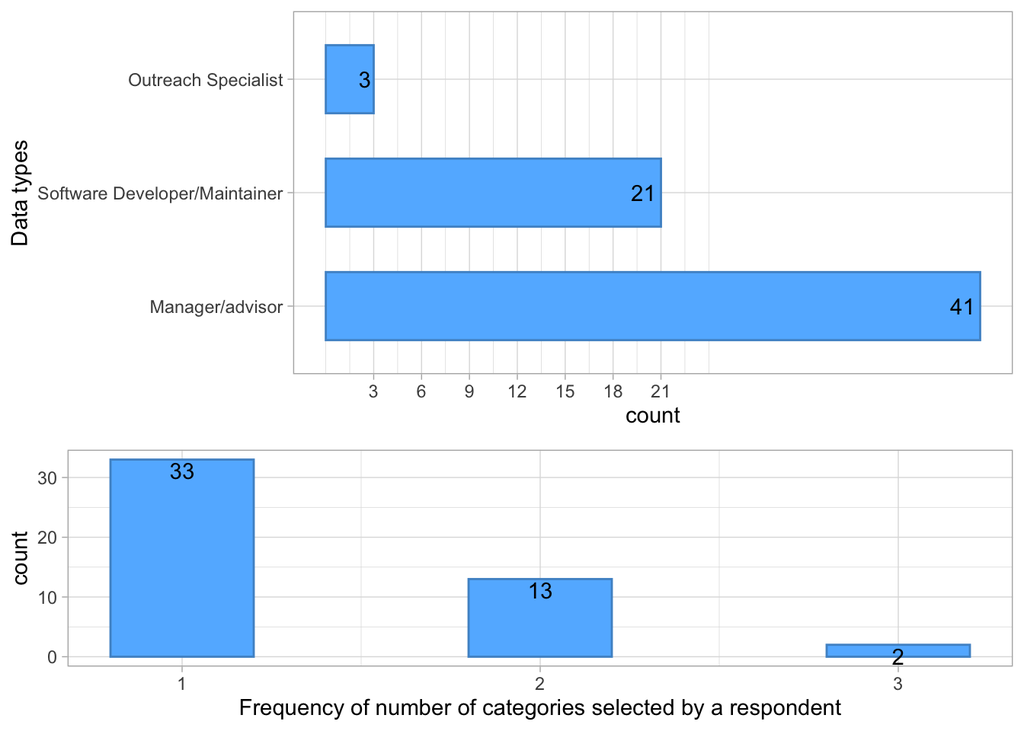

```r
ggpubr::ggarrange(
## Frequency distribution of the categories
tab.Roles %>% separate(col = vals, into = c("vals", "fat"), sep = " - ") %>% select(-fat) %>%
ggplot(aes(y = forcats::fct_infreq(vals))) +
  geom_bar(fill = "steelblue1", col = "steelblue3", width = 0.6) +
  geom_text(stat = 'count', aes(label = after_stat(count)), hjust = 1.2) +
  scale_x_continuous(breaks = seq(3, 21, by = 3)) +
  labs(x = "count", y = "Data types") +
  theme_light(),

## How many single and multiple responses
tab.Roles %>% group_by(Timestamp) %>%
  summarise(answers_freq = max(answer_count)) %>% ungroup() %>%
  ggplot(aes(answers_freq)) +
  geom_bar(fill = "steelblue1", col = "steelblue3", width = 0.4) +
  geom_text(stat = 'count', aes(label = after_stat(count)), vjust = 1.2) +
  scale_x_continuous(breaks = 1:6) +
  labs(y = "count", x = "Frequency of number of categories selected by a respondent") +
  theme_light(),
  ncol = 1, heights = c(1.5, 1)
)
```

## Ques4: Distribution of projects involvement/experience.

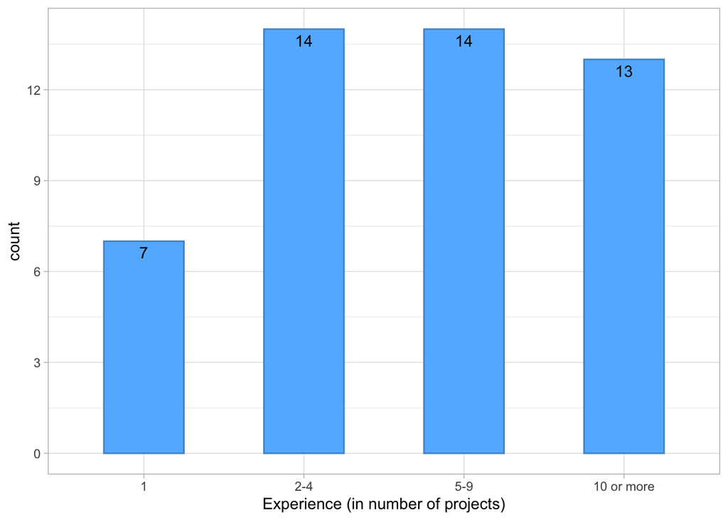

```r
tab.Experience <- wdat %>% select(Timestamp, experience) %>%
  mutate(experience = fct_relevel(factor(experience), "1", "2-4", "5-9"))

tab.Experience %>% ggplot(aes(x = experience)) +
geom_bar(fill = "steelblue1", col = "steelblue3", width = 0.5) +
  geom_text(stat = 'count', aes(label = after_stat(count)), vjust = 1.5) +
  labs(y = "count", x = "Experience (in number of projects)") +
  scale_y_continuous(breaks = seq(0,15, by = 3)) +
  theme_light()
```